# Machine Learning Assignment

Kyu

January 18, 2016

In this assignment, you will be working with data from the SeaFlow environmental flow cytometry instrument.

A flow cytometer delivers a flow of particles through capilliary. By shining lasers of different wavelengths and measuring the absorption and refraction patterns, you can determine how large the particle is and some information about its color and other properties, allowing you to detect it.

The technology was developed for medical applciations, where the particles were potential pathogens in, say, serum, and the goal was to give a diagnosis. But the technology was adapted for use in environmental science to understand microbial population profiles.

The SeaFlow instrument, developed by the Armbrust Lab at the University of Washington, is unique in that it is deployed on research vessels and takes continuous measurements of population profiles in the open ocean.

The scale of the data can be quite large, and is expected to grow significantly: A two-week cruise from one vessel can generate hundreds of gigabytes per day, and the vision is to deploy one of these instruments on not only research vessels but the commercial shipping fleet as well.

While there are a number of challenging analytics tasks associated with this data, a central task is classification of particles. Based on the optical measurements of the particle, it can be identified as one of several populations.

```r
library(caret)
```

```r
library(ggplot2)
library(rpart)
library(rpart.plot)
library(rattle)
library(randomForest)
library(e1071)
library(parallel)
library(doParallel)
```

# Understanding Data

```r
setwd("E:/Google Drive/College/20-Data Science at Scale/2 - Practical Predictive Analytics_Models and Methods/assignment/data")
data = read.csv("seaflow_21min.csv")

summary(data)
```

```
##     file_id           time          cell_id            d1
##  Min.   :203.0   Min.   : 12.0   Min.   :    0   Min.   : 1328
##  1st Qu.:204.0   1st Qu.:174.0   1st Qu.: 7486   1st Qu.: 7296
##  Median :206.0   Median :362.0   Median :14995   Median :17728
##  Mean   :206.2   Mean   :341.5   Mean   :15008   Mean   :17039
##  3rd Qu.:208.0   3rd Qu.:503.0   3rd Qu.:22401   3rd Qu.:24512
##  Max.   :209.0   Max.   :643.0   Max.   :32081   Max.   :54048
##        d2          fsc_small        fsc_perp        fsc_big
##  Min.   :   32   Min.   :10005   Min.   :    0   Min.   :32384
##  1st Qu.: 9584   1st Qu.:31341   1st Qu.:13496   1st Qu.:32400
##  Median :18512   Median :35483   Median :18069   Median :32400
##  Mean   :17437   Mean   :34919   Mean   :17646   Mean   :32405
##  3rd Qu.:24656   3rd Qu.:39184   3rd Qu.:22243   3rd Qu.:32416
##  Max.   :54688   Max.   :65424   Max.   :63456   Max.   :32464
##        pe          chl_small        chl_big           pop
##  Min.   :    0   Min.   : 3485   Min.   :    0   crypto :  102
##  1st Qu.: 1635   1st Qu.:22525   1st Qu.: 2800   nano   :12698
##  Median : 2421   Median :30512   Median : 7744   pico   :20860
##  Mean   : 5325   Mean   :30164   Mean   : 8328   synecho:18146
##  3rd Qu.: 5854   3rd Qu.:38299   3rd Qu.:12880   ultra  :20537
##  Max.   :58675   Max.   :64832   Max.   :57184
```

```r
str(data)
```

```
## 'data.frame':    72343 obs. of  12 variables:
##  $ file_id  : int  203 203 203 203 203 203 203 203 203 203 ...
##  $ time     : int  12 12 12 12 12 12 12 12 12 12 ...
##  $ cell_id  : int  1 4 6 9 11 15 17 23 24 26 ...
##  $ d1       : int  25344 12960 21424 7712 30368 30032 28704 17008 4896 31312 ...
##  $ d2       : int  27968 22144 23008 14528 21440 22704 21664 7072 13104 22608 ...
##  $ fsc_small: int  34677 37275 31725 28744 28861 31221 37539 38987 25515 34133 ...
##  $ fsc_perp : int  14944 20440 11253 10219 6101 13488 17944 20315 5995 21829 ...
##  $ fsc_big  : int  32400 32400 32384 32416 32400 32400 32400 32416 32400 32400 ...
##  $ pe       : int  2216 1795 1901 1248 12989 1883 2107 1509 1952 2525 ...
##  $ chl_small: int  28237 36755 26640 35392 23421 27323 34627 36680 29621 28205 ...
##  $ chl_big  : int  5072 14224 0 10704 5920 6560 11072 15072 3040 2336 ...
##  $ pop      : Factor w/ 5 levels "crypto","nano",..: 3 5 3 5 4 3 5 5 3 3 ...
```

# Spliting Data

```r
set.seed(123)
trainIndex = createDataPartition(y=data$pop, p=.5,list=FALSE)
train = data[trainIndex,]
test = data[-trainIndex,]
```

# Graph

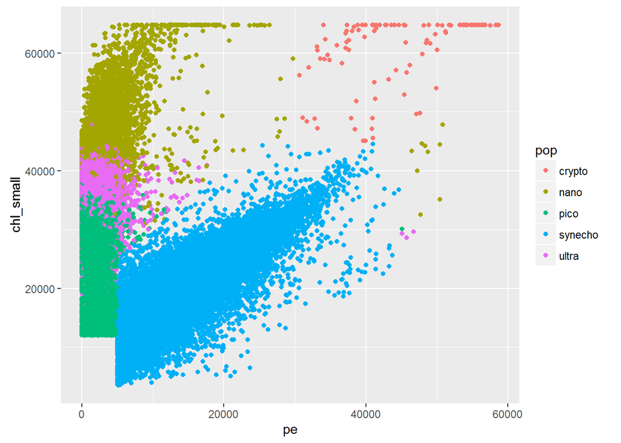

```r
qplot(pe, chl_small, data = data, color = pop)
```

# Build Rpart Model

```r
model_rp = rpart(pop ~ fsc_small + fsc_perp + fsc_big + pe + chl_big + chl_small, method="class", data=train)

# Displaying tree
print(model_rp)
```

```
## n= 36172
##
## node), split, n, loss, yval, (yprob)
##       * denotes terminal node
##
##  1) root 36172 25742 pico (0.0014 0.18 0.29 0.25 0.28)
##    2) pe< 5000 26339 15951 pico (0 0.22 0.39 0 0.38)
##      4) chl_small< 32526.5 11763  2148 pico (0 0.00026 0.82 0 0.18) *
##      5) chl_small>=32526.5 14576  6591 ultra (0 0.4 0.053 0 0.55)
##       10) chl_small>=41302.5 5204   670 nano (0 0.87 0.00019 0 0.13) *
##       11) chl_small< 41302.5 9372  2056 ultra (0 0.14 0.082 0 0.78) *
##    3) pe>=5000 9833   760 synecho (0.0052 0.054 0.0043 0.92 0.014)
##      6) chl_small>=37386.5 647   133 nano (0.079 0.79 0 0.062 0.065) *
##      7) chl_small< 37386.5 9186   153 synecho (0 0.0015 0.0046 0.98 0.011) *
```

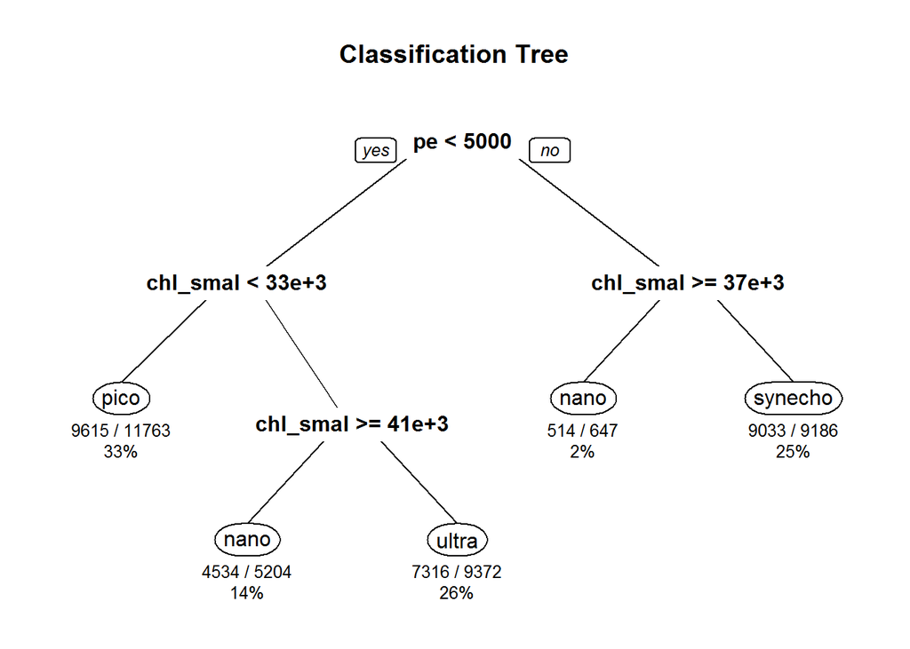

```r
rpart.plot(model_rp, main="Classification Tree", extra=102, under=TRUE, faclen=0)
```

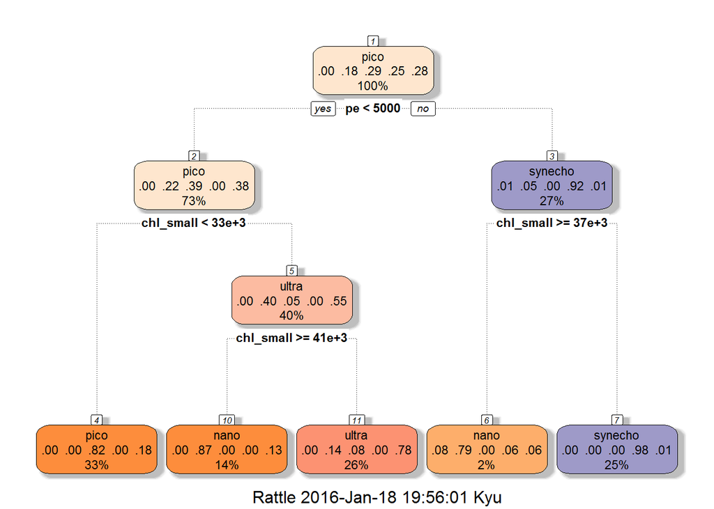

```r
fancyRpartPlot(model_rp, palettes=c("Greys", "Oranges"))
```

# Prediction and Evaluation

```r
pred_rp = predict(model_rp, test, type='class')
table(test$pop, pred_rp)
```

```
##          pred_rp
##           crypto nano pico synecho ultra
##   crypto       0   51    0       0     0
##   nano         0 5016    4       6  1323
##   pico         0    0 9589      55   786
##   synecho      0   61    0    9012     0
##   ultra        0  710 2237      94  7227
```

```r
pred_result_rp = pred_rp == test$pop
sum(pred_result_rp) / length(pred_result_rp)
```

```
## [1] 0.8527273
```

```r
summary(pred_rp == test$pop)
```

```
##    Mode   FALSE    TRUE    NA's
## logical    5327   30844       0
```

```r
30844/(30844+5327)
```

```
## [1] 0.8527273
```

```r
acc_rp = confusionMatrix(pred_rp, test$pop)$overall['Accuracy']
acc_rp
```

```
##  Accuracy
## 0.8527273
```

# Corss validation

```r
# Cross validation
set.seed(123)
numFolds = trainControl(method="cv", number=10, repeats=10, allowParallel=TRUE)
cartGrid = expand.grid(.cp = seq(0.002,0.1,0.002))
train(pop ~ fsc_small + fsc_perp + fsc_big + pe + chl_big + chl_small, data=train, method="rpart",trControl=numFolds, tuneGrid=cartGrid)
```

```
## CART
##
## 36172 samples
##    11 predictor
##     5 classes: 'crypto', 'nano', 'pico', 'synecho', 'ultra'
##
## No pre-processing
## Resampling: Cross-Validated (10 fold)
## Summary of sample sizes: 32555, 32555, 32554, 32555, 32555, 32556, ...
## Resampling results across tuning parameters:
##
##   cp     Accuracy   Kappa      Accuracy SD  Kappa SD
##   0.002  0.8847730  0.8444921  0.004382298  0.005902500
##   0.004  0.8692081  0.8237023  0.003351138  0.004577586
##   0.006  0.8627116  0.8146448  0.005036078  0.006835753
##   0.008  0.8556062  0.8050276  0.005040431  0.006849244
##   0.010  0.8556062  0.8050276  0.005040431  0.006849244
##   0.012  0.8556062  0.8050276  0.005040431  0.006849244
##   0.014  0.8556062  0.8050276  0.005040431  0.006849244
##   0.016  0.8556062  0.8050276  0.005040431  0.006849244
##   0.018  0.8540303  0.8028564  0.007069419  0.009646357
##   0.020  0.8428062  0.7873662  0.005994834  0.008167829
##   0.022  0.8428062  0.7873662  0.005994834  0.008167829
##   0.024  0.8428062  0.7873662  0.005994834  0.008167829
##   0.026  0.8428062  0.7873662  0.005994834  0.008167829
##   0.028  0.8428062  0.7873662  0.005994834  0.008167829
##   0.030  0.8428062  0.7873662  0.005994834  0.008167829
##   0.032  0.8428062  0.7873662  0.005994834  0.008167829
##   0.034  0.8428062  0.7873662  0.005994834  0.008167829
##   0.036  0.8428062  0.7873662  0.005994834  0.008167829
##   0.038  0.8428062  0.7873662  0.005994834  0.008167829
##   0.040  0.8428062  0.7873662  0.005994834  0.008167829
##   0.042  0.8428062  0.7873662  0.005994834  0.008167829
##   0.044  0.8428062  0.7873662  0.005994834  0.008167829
##   0.046  0.8428062  0.7873662  0.005994834  0.008167829
##   0.048  0.8428062  0.7873662  0.005994834  0.008167829
##   0.050  0.8428062  0.7873662  0.005994834  0.008167829
##   0.052  0.8428062  0.7873662  0.005994834  0.008167829
##   0.054  0.8428062  0.7873662  0.005994834  0.008167829
##   0.056  0.8428062  0.7873662  0.005994834  0.008167829
```

[output cut: 10 more lines]

```
##   0.078  0.8428062  0.7873662  0.005994834  0.008167829
##   0.080  0.8428062  0.7873662  0.005994834  0.008167829
##   0.082  0.8428062  0.7873662  0.005994834  0.008167829
##   0.084  0.8428062  0.7873662  0.005994834  0.008167829
##   0.086  0.8428062  0.7873662  0.005994834  0.008167829
##   0.088  0.8428062  0.7873662  0.005994834  0.008167829
##   0.090  0.8428062  0.7873662  0.005994834  0.008167829
##   0.092  0.8428062  0.7873662  0.005994834  0.008167829
##   0.094  0.8428062  0.7873662  0.005994834  0.008167829
##   0.096  0.8428062  0.7873662  0.005994834  0.008167829
##   0.098  0.8428062  0.7873662  0.005994834  0.008167829
##   0.100  0.8428062  0.7873662  0.005994834  0.008167829
##
## Accuracy was used to select the optimal model using  the largest value.
## The final value used for the model was cp = 0.002.
```

```r
# Build rpart model with cv
model_rp_cv = rpart(pop ~ fsc_small + fsc_perp + fsc_big + pe + chl_big + chl_small, method="class", data=train, cp=0.002)
pred_rp_cv = predict(model_rp_cv, test, type="class")
acc_rp_cv = confusionMatrix(pred_rp_cv, test$pop)$overall['Accuracy']
acc_rp_cv
```

```
##  Accuracy
## 0.8834702
```

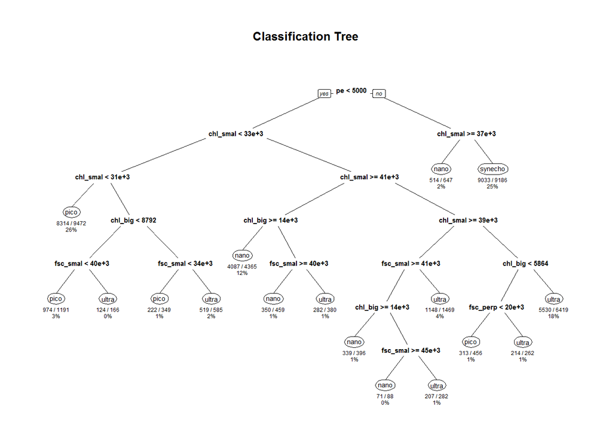

```r
# Ploting
prp(model_rp_cv, main="Classification Tree", extra=102, under=TRUE, faclen=0)
```

# Build RandomForest Model

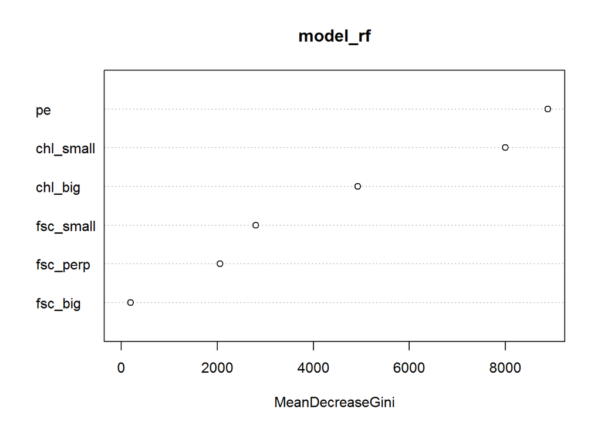

```r
model_rf = randomForest(pop ~ fsc_small + fsc_perp + fsc_big + pe + chl_big + chl_small, method="class", data=train)

# Important keys
varImpPlot(model_rf)
```

```r
imp_rf = importance(model_rf)
sort(imp_rf[,1], decreasing=TRUE)
```

```
##        pe chl_small   chl_big fsc_small  fsc_perp   fsc_big
## 8880.9619 8002.8532 4921.9824 2804.4113 2051.2233  194.2251
```

# Prediction and Evaluation

```r
pred_rf = predict(model_rf, test, type='class')
table(test$pop, pred_rp)
```

```
##          pred_rp
##           crypto nano pico synecho ultra
##   crypto       0   51    0       0     0
##   nano         0 5016    4       6  1323
##   pico         0    0 9589      55   786
##   synecho      0   61    0    9012     0
##   ultra        0  710 2237      94  7227
```

```r
pred_result_rf = pred_rf == test$pop
sum(pred_result_rf) / length(pred_result_rf)
```

```
## [1] 0.9190512
```

```r
summary(pred_rf == test$pop)
```

```
##    Mode   FALSE    TRUE    NA's
## logical    2928   33243       0
```

```r
33243/(33243+2928)
```

```
## [1] 0.9190512
```

```r
acc_rf = confusionMatrix(pred_rf, test$pop)$overall['Accuracy']
acc_rf
```

```
##  Accuracy
## 0.9190512
```

# Corss validation

```r
# Cross validation
set.seed(123)

registerDoParallel(makeCluster(detectCores()))
controlf = trainControl(method="cv", number=10, repeats=10, allowParallel = TRUE)
mtryGrid = expand.grid(mtry = 100)
model_rf_cv = randomForest(pop ~ fsc_small + fsc_perp + fsc_big + pe + chl_big + chl_small, data=train, method="class", trControl = controlf, tuneGrid=mtryGrid)

# Build rpart model with cv
pred_rf_cv = predict(model_rf_cv, test)
acc_rf_cv = confusionMatrix(pred_rf_cv, test$pop)$overall['Accuracy']
acc_rf_cv
```

```
##  Accuracy
## 0.9190788
```

# Build Suport Vector Machine Model

```r
model_svm <- svm(pop ~ fsc_small + fsc_perp + fsc_big + pe + chl_big + chl_small, data=train)
```

# Prediction and Evaluation

```r
pred_svm = predict(model_svm, test, type='class')
table(test$pop, pred_svm)
```

```
##          pred_svm
##           crypto  nano  pico synecho ultra
##   crypto      48     3     0       0     0
##   nano         1  5577     0       2   769
##   pico         0     0 10047      56   327
##   synecho      1     2    21    9047     2
##   ultra        0   372  1356       6  8534
```

```r
pred_result_svm = pred_svm == test$pop
sum(pred_result_svm) / length(pred_result_svm)
```

```
## [1] 0.9193276
```

```r
summary(pred_svm == test$pop)
```

```
##    Mode   FALSE    TRUE    NA's
## logical    2918   33253       0
```

```r
33253/(33253+2918)
```

```
## [1] 0.9193276
```

```r
acc_svm = confusionMatrix(pred_svm, test$pop)$overall['Accuracy']
acc_svm
```

```
##  Accuracy
## 0.9193276
```

# Modifying Data set

```r
train_cleaned = subset(train, file_id != 208)
test_cleaned = subset(test, file_id != 208)
```

# Build Suport Vector Machine Model

```r
model_svm_2 <- svm(pop ~ fsc_small + fsc_perp + fsc_big + pe + chl_big + chl_small, data=train_cleaned)
```

# Prediction and Evaluation

```r
pred_svm_2 = predict(model_svm_2, test_cleaned, type='class')
table(test_cleaned$pop, pred_svm_2)
```

```
##          pred_svm_2
##           crypto nano pico synecho ultra
##   crypto      40    2    0       1     0
##   nano         1 4596    0       1   166
##   pico         0    0 9728      47   182
##   synecho      1    2   26    7054     0
##   ultra        0  217  208       5  7812
```

```r
pred_result_svm_2 = pred_svm_2 == test_cleaned$pop
sum(pred_result_svm_2) / length(pred_result_svm_2)
```

```
## [1] 0.9714514
```

```r
summary(pred_svm_2 == test_cleaned$pop)
```

```
##    Mode   FALSE    TRUE    NA's
## logical     859   29230       0
```

```r
33253/(33253+2918)
```

```
## [1] 0.9193276
```

```r
acc_svm_2 = confusionMatrix(pred_svm_2, test_cleaned$pop)$overall['Accuracy']
acc_svm_2
```

```
##  Accuracy
## 0.9714514
```

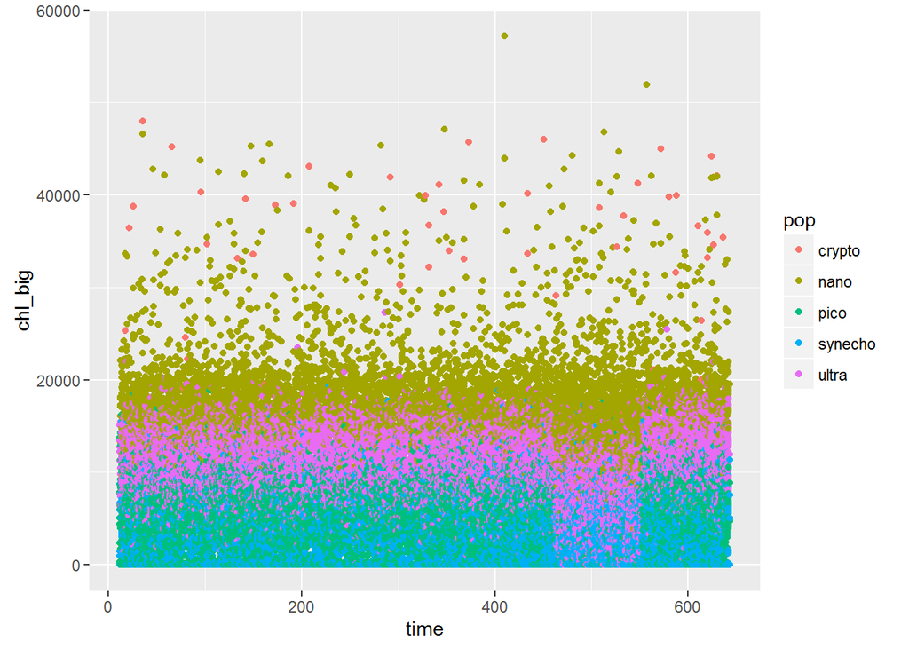

```r
qplot(time, chl_big, data = train, color = pop)
```